# Multiple SSF’s with Fisher data

John Fieberg & Johannes Signer

**Purpose**: demonstrate methods for analyzing data from multiple animals, allowing for multiple random slopes.

# Setup

Load libraries

```r
library(glmmTMB)
library(tidyverse)
library(survival)
library(TwoStepCLogit)
library(amt)
library(terra)
library(here)
library(broom)
library(tictoc)
options(width=165)
knitr::opts_chunk$set(fig.width=12,fig.height=4.5, error=TRUE)
set.seed(09081940)
```

Record time for running all code

```r
tic("total")
```

## Environmental data

Read in and process the environmental data layers (elevation, population density. forest)

```r
# Read in data
elevation <- rast(here("Resource-and-Step-Selection-Analyses/Data/elevation/", "ASTER ASTGTM2 Elevation-20100101120000000-0-0.tif"))
landuse <- rast(here("Resource-and-Step-Selection-Analyses/Data/landuse", "landuse_study_area.tif"))
popden <- rast(here("Resource-and-Step-Selection-Analyses/Data/pop_den", "pop_den.tif"))

# Center and scale elevation and popden
elevation[] <- (elevation[] - mean(elevation[], na.rm = TRUE))/sd(elevation[], na.rm = TRUE)
popden[] <- (popden[] - mean(popden[], na.rm = TRUE))/sd(popden[], na.rm = TRUE)

# Reproject rasters to EPSG:5070
landuse <- project(landuse, "EPSG:5070")
elevation <- project(elevation, landuse)
popden <- project(popden, landuse)

# Create a binary layer where landuse classes 41 to 43 represent forest
forest <- landuse %in% 41:43
names(elevation)<-"elevation"
names(forest)<-"forest"
names(popden)<-"popden"
```

Plot the layers

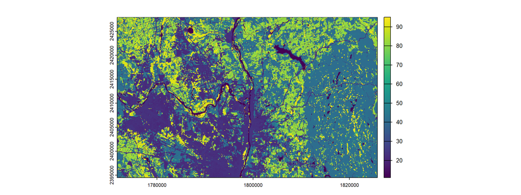

```r
plot(landuse)
```

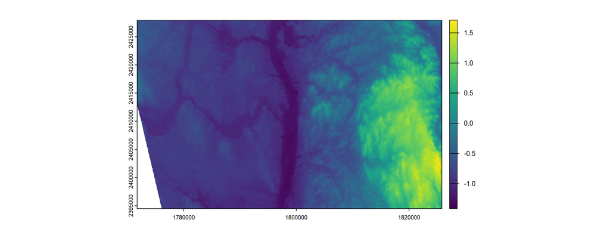

```r
plot(elevation)
```

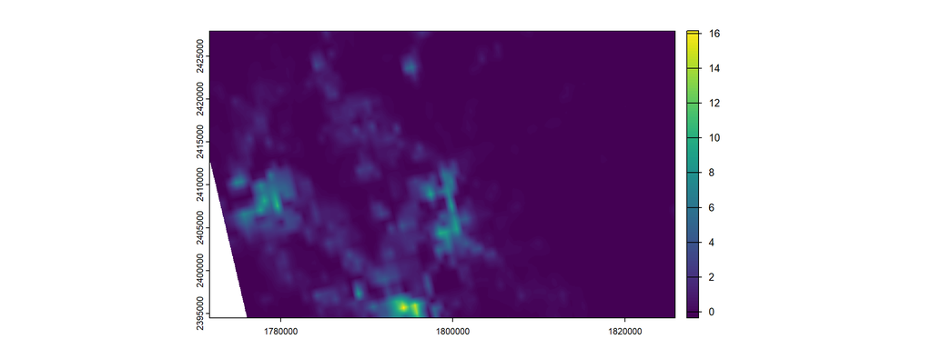

```r
plot(popden)
```

## Fisher data

Load the fisher data

```r
dat <- read_csv(here("Resource-and-Step-Selection-Analyses/Data", "fisher_data.csv")) %>%
  filter(id %in% c(1465, 1466, 1072, 1078, 1016, 1469))
```

We will make use of nested data frames in R, which will allow us to apply functions separately to data from each individual using the map functions in the Purr pacakge. If you are unfamiliar with `purrr` syntax, may want to view one or more of the tutorials, below, or make use of the [purrr cheat sheet](https://github.com/rstudio/cheatsheets/blob/master/purrr.pdf).

- http://www.rebeccabarter.com/blog/2019-08-19_purrr/
- https://www.r-bloggers.com/2020/05/one-stop-tutorial-on-purrr-package-in-r/
- https://jennybc.github.io/purrr-tutorial/index.html

```r
dat_all <- dat %>% nest(data=c(x,y,t))
```

Add sex as a column of the nested data frame

```r
dat_all$sex <- c("f", "f", "f", "m", "m", "m")
```

Create tracks with an appropriate coordinate reference system using the amt package

```r
dat_all <- dat_all %>%
  mutate(trk = map(data, function(d) {
    make_track(d, x, y, t, crs = 4326) %>%
      transform_coords(crs_to = 5070)
  }))
dat_all
```

```
## # A tibble: 6 × 4
##      id data                 sex   trk
##   <dbl> <list>               <chr> <list>
## 1  1072 <tibble [1,349 × 3]> f     <trck_xyt [1,349 × 3]>
## 2  1465 <tibble [3,004 × 3]> f     <trck_xyt [3,004 × 3]>
## 3  1466 <tibble [1,501 × 3]> f     <trck_xyt [1,501 × 3]>
## 4  1078 <tibble [1,638 × 3]> m     <trck_xyt [1,638 × 3]>
## 5  1469 <tibble [2,436 × 3]> m     <trck_xyt [2,436 × 3]>
## 6  1016 <tibble [8,958 × 3]> m     <trck_xyt [8,958 × 3]>
```

Summarize sampling rates,

```r
dat_all %>% mutate(sr = map(trk, summarize_sampling_rate)) %>%
  dplyr::select(id, sr) %>% unnest(cols=c(sr))
```

```
## # A tibble: 6 × 10
##      id   min    q1 median  mean    q3   max    sd     n unit
##   <dbl> <dbl> <dbl>  <dbl> <dbl> <dbl> <dbl> <dbl> <int> <chr>
## 1  1072 3.92   9.8   10.0  20.7  10.3  1650.  95.2  1348 min
## 2  1465 0.4    1.97   2.03  8.93  3.98 1080.  48.1  3003 min
## 3  1466 0.417  1.97   2.07 15.7   4.08 2167. 104.   1500 min
## 4  1078 1.35   9.78  10.0  21.7  10.3  2111.  87.2  1637 min
## 5  1469 0.417  1.97   2.17 13.3   5.42 2889.  90.2  2435 min
## 6  1016 0.1    1.93   2.03  8.04  2.57 1209.  44.0  8957 min
```

10 minutes seems to appropriate for all animals.

# Prepare data for fitting step-selection functions

First, we will create a semi-regular trajectory by subsampling the track to include locations that are separated by 10 +/- 2 minutes.

```r
dat1 <- dat_all %>% mutate(dat_clean = map(trk, ~ {
  .x %>% track_resample(rate = minutes(10), tolerance = seconds(120))
}))
```

Rather than fit tentative step length and turn angle distributions to each individual separately, we will pool the data and fit a single gamma distribution to the **pooled** step length data and a single von-Mises distribution to the pooled turn angle data.

We will then generate random steps using these distributions and include step length, log(step length), and cos(turn angle) in the model as both fixed and random effects. That will allow each individual to have its own movement kernel with the fixed effects used to update the movement kernel for a “typical” individual (one with all random effects set to 0). The random effects will be used to update the movement kernel for all observed individuals in the data set. These updates can be accomplished using the [mixedSSA package](https://github.com/smthfrmn/mixedSSA). Here, we will largely focus on the habitat selection parameters and the mean correction factors for the movement parameters (needed to estimate the movement kernel for a “typical” individual).

First, create a steps version of the data set using the steps_by_burst function applied to the data from each individual. We will unnest the data so that we can fit a single set of distributions to the pooled step length and turn angle data.

```r
dat_ssf <- dat1 %>%
  mutate(stps = map(dat_clean, ~ .x %>%
                      steps_by_burst())) %>%
  select(id, sex, stps) %>%
  unnest(stps)
```

Unfortunately, some of the classes were lost in the process, so we have to add some of the classes back on to the object.

```r
class(dat_ssf) <- c("bursted_steps_xyt", "steps_xyt", "steps_xy", class(dat_ssf))
```

Now, we can pool the steps across individuals to fit a single tentative distribution to the step lengths and turn angles, and use this distribution to generate random steps. Also, we will extract the covariates at the end of the observed and random steps.

```r
dat_ssf2 <- dat_ssf %>% random_steps() %>%
  extract_covariates(elevation) %>%
  extract_covariates(popden) %>%
  extract_covariates(forest) %>%
  mutate(
    y = as.numeric(case_),
    id = as.numeric(factor(id)),
    cos_ta_= cos(ta_),
    log_sl_ = log(sl_),
    step_id = paste(id, step_id_, sep = ":")) %>%
    dplyr::select(id, sex, y, step_id, elevation, popden, forest,
                  cos_ta_, log_sl_, sl_, ta_)
```

create forest indicator variable (1 if forest, 0 otherwise)

```r
dat_ssf2$forest <- as.numeric(dat_ssf2$forest)
```

# Models

## glmmTMB: random slopes model

The process is the same as for the mixed RSF:

1. Set up model, but do not fit it
2. Set random intercept variance to large fixed value, set other variance components to 0
3. Fit the model

However, there are a few differences:

- we will use a Poisson likelihood rather than logistic
- we won’t need weights
- we will include fixed intercepts for each step_id

In our model below, we will assume all coefficients vary independently since we have so few individuals. With more individuals, we could estimate covariances between the random effects. The “(0 + x | id)” is used to let R know that we want to model random coefficients for x and that these coefficients should vary indepdently of the intercept or other random effects included in the model.

```r
tic("mixed ssf")
fisher.tmp <- glmmTMB(y ~ elevation + popden + forest  +
                        (1|step_id) +
                        sl_ + log_sl_ + cos_ta_ +
                        (0+ sl_|id) + (0+log_sl_|id) + (0+cos_ta_|id)+
                        (0 + elevation|id) + (0 + popden|id) + (0+ forest |id)
                      , family=poisson(), data = dat_ssf2,
                      doFit=FALSE)
```

Set variance of random intercept to 10^6 and fit the model

```r
fisher.tmp$parameters$theta[1] <- log(1e3)
nvarparm<-length(fisher.tmp$parameters$theta)
fisher.tmp$mapArg <- list(theta=factor(c(NA,1:(nvarparm-1))))
fisher.ssf <- glmmTMB:::fitTMB(fisher.tmp)
summary(fisher.ssf)
```

```
##  Family: poisson  ( log )
## Formula:          y ~ elevation + popden + forest + (1 | step_id) + sl_ + log_sl_ +      cos_ta_ + (0 + sl_ | id) + (0 + log_sl_ | id) + (0 + cos_ta_ |
##     id) + (0 + elevation | id) + (0 + popden | id) + (0 + forest |      id)
## Data: dat_ssf2
##
##       AIC       BIC    logLik -2*log(L)  df.resid
##  107964.1  108081.7  -53969.1  107938.1     62833
##
## Random effects:
##
## Conditional model:
##  Groups  Name        Variance  Std.Dev.
##  step_id (Intercept) 1.000e+06 1.000e+03
##  id      sl_         1.272e-06 1.128e-03
##  id.1    log_sl_     4.514e-02 2.125e-01
##  id.2    cos_ta_     8.529e-02 2.921e-01
##  id.3    elevation   2.901e+01 5.386e+00
##  id.4    popden      6.042e-02 2.458e-01
##  id.5    forest      2.232e-02 1.494e-01
## Number of obs: 62846, groups:  step_id, 5757; id, 6
##
## Conditional model:
##               Estimate Std. Error z value Pr(>|z|)
## (Intercept) -2.247e+01  2.812e+00  -7.990 1.35e-15 ***
## elevation    7.019e+00  2.560e+00   2.742  0.00611 **
## popden      -4.761e-01  1.794e-01  -2.653  0.00797 **
## forest       4.532e-01  7.701e-02   5.886 3.96e-09 ***
## sl_         -2.903e-04  5.161e-04  -0.562  0.57378
## log_sl_      1.329e-01  8.940e-02   1.486  0.13716
## cos_ta_      9.334e-02  1.219e-01   0.766  0.44387
## ---
## Signif. codes:  0 '***' 0.001 '**' 0.01 '*' 0.05 '.' 0.1 ' ' 1
```

```r
toc()
```

```
## mixed ssf: 132.22 sec elapsed
```

## Using Ts.Estim (a formal two-step approach)

```r
library(TwoStepCLogit)
```

This will use a formal two-step approach to estimating the variances of the random coefficients, accounting for sampling variability. By defualt, the method assumes the coefficients vary independent of each other, but this can be changed by adding the argument D = “UN”

```r
tic("two-step")
twostep<-Ts.estim(formula = y ~  elevation+ popden+forest+
           sl_ + log_sl_ + cos_ta_ +
           strata(step_id) +cluster(id),
           data = dat_ssf2,
           random = ~ elevation + popden + forest + sl_ + log_sl_ + cos_ta_, all.m.1=F)
twostep
```

```
## Call:
## Ts.estim(formula = y ~ elevation + popden + forest + sl_ + log_sl_ +
##     cos_ta_ + strata(step_id) + cluster(id), data = dat_ssf2,
##     random = ~elevation + popden + forest + sl_ + log_sl_ + cos_ta_,
##     all.m.1 = F)
##
## beta coefficients:
##             estimate        se
## elevation   7.480833  2.909494
## popden     -0.491391  0.185038
## forest      0.448103  0.086509
## sl_        -0.000295  0.000575
## log_sl_     0.138253  0.099612
## cos_ta_     0.093310  0.132940
##
## D = estimate of the between-cluster variance-covariance matrix D,
##     for the random coefficients only:
##            elevation      popden      forest           sl_    log_sl_    cos_ta_
## elevation   43.39271  0.00000000  0.00000000  0.000000e+00  0.0000000  0.0000000
## popden       0.00000  0.08754849  0.00000000  0.000000e+00  0.0000000  0.0000000
## forest       0.00000  0.00000000  0.03126602  0.000000e+00  0.0000000  0.0000000
## sl_          0.00000  0.00000000  0.00000000  1.650452e-06  0.0000000  0.0000000
## log_sl_      0.00000  0.00000000  0.00000000  0.000000e+00  0.0565104  0.0000000
## cos_ta_      0.00000  0.00000000  0.00000000  0.000000e+00  0.0000000  0.1021731
```

```r
toc()
```

```
## two-step: 1.28 sec elapsed
```

## Individual fits

Next, we will fit a model separately to each individual and then capture and process the coefficients in a second stage.

```r
ssffits <- dat_ssf2 %>%  nest(data = -c(id, sex)) %>%
  mutate(mod = map(data, function(x) (fit_issf(y ~ elevation + popden + forest +
                                        sl_ + log_sl_ + cos_ta_ +strata(step_id),
                                        data = x))))
```

Now, summarize fits to individual animals

```r
ssffits2 <- ssffits %>%
  mutate(tidy = map(mod, ~ broom::tidy(.x$model)),
         n = map_int(data, nrow)) %>%
  unnest(tidy) %>%
  dplyr::select(-c(data, mod)) %>%
  filter(term!="(Intercept)")

# Mean coefficient and SE
se<-function(x){sd(x)/sqrt(length(x))}
ssffits2 %>% filter(term!="(Intercept)") %>%
  group_by(term) %>%
  summarize(mean=mean(estimate), se=se(estimate))
```

```
## # A tibble: 6 × 3
##   term           mean       se
##   <chr>         <dbl>    <dbl>
## 1 cos_ta_    0.0971   0.132
## 2 elevation  8.86     3.55
## 3 forest     0.436    0.0849
## 4 log_sl_    0.146    0.0984
## 5 popden    -0.757    0.283
## 6 sl_       -0.000436 0.000647
```

# Graphical Comparison of Results

## Mean coefficients

```r
# Dataset with mean coefficients from individual fits
betas1<-ssffits2 %>%
  filter(term!="(Intercept)") %>%
  group_by(term) %>%
  summarize(mean=mean(estimate), se=se(estimate)) %>%
  mutate(method="indiv_fits") %>%
  select(mean, se, method, term)

# Mean coefficients from mixed model (dropping the intercept)
betas2<-data.frame(mean=summary(fisher.ssf)$coef$cond[-1,1],
                   se = summary(fisher.ssf)$coef$cond[-1,2])
betas2$method<-"Mixed"
betas2$term<-c("elevation", "popden", "forest", "sl_", "log_sl_", "cos_ta_")


# Mean coefficients from TWO-STEP (TS.Estim)
betas3<-data.frame(mean=twostep$beta, method=rep("two_step",3),
                   se = twostep$se,
                   term=c("elevation", "popden", "forest", "sl_", "log_sl_", "cos_ta_"))

all_means <- rbind(betas1, betas2, betas3)
```

Plot the results. Estimates of mean coefficients are similar using all 3 methods, though the point estimates differ slightly for elevation and popden due to a few individuals with poorly estimated coefficients that are also far from the mean.

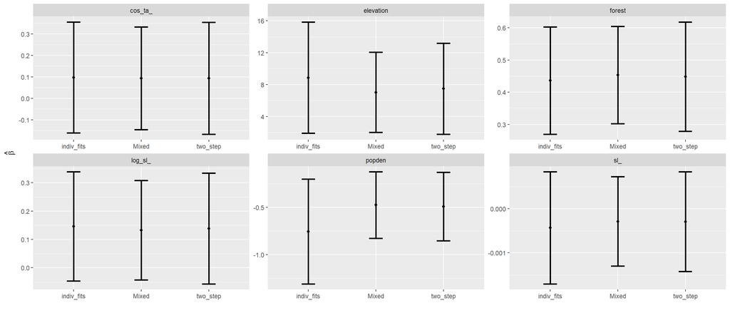

```r
ggplot(data = all_means, aes(x = method, y = mean)) +
  geom_point() +
  geom_errorbar( aes(x = method, ymin = mean - 1.96*se, ymax = mean + 1.96*se),
                 width=0.2, linewidth=1) +
  xlab("") + ylab(expression(hat(beta))) +
    facet_wrap(~term, scales="free")
```

## Variance parameters

Compare variance of individual estimates to variance component from mixed model.

```r
# Variance of the coefficients from the individual fits (this will be biased high)
varpar1 <- ssffits2 %>% filter(term!="(Intercept)") %>%
  group_by(term) %>%
  summarize(sd=sd(estimate)) %>%
  mutate(method = "Individual fits") %>%
  select(sd, method, term)

# Variance estimated by the mixed model
varpar2 <- data.frame(sd = sqrt(as.numeric(VarCorr(fisher.ssf)$cond[-1]))) %>%
  mutate(method = "Mixed",
         term = c("sl_", "log_sl_", "cos_ta_","elevation", "popden", "forest"))


# Variance using the formal two step appraoch
varpar3 <- data.frame(sd = diag(sqrt(twostep$D))) %>%
  mutate(method = "two_step",
         term=c("elevation", "popden", "forest", "sl_", "log_sl_", "cos_ta_"))

# Combine into a single data frame for plotting
allvars <- rbind(varpar1, varpar2, varpar3)
```

Plot the estimated variance parameters. Here we see that var(individual fits) > var(two step) > var(mixed model).

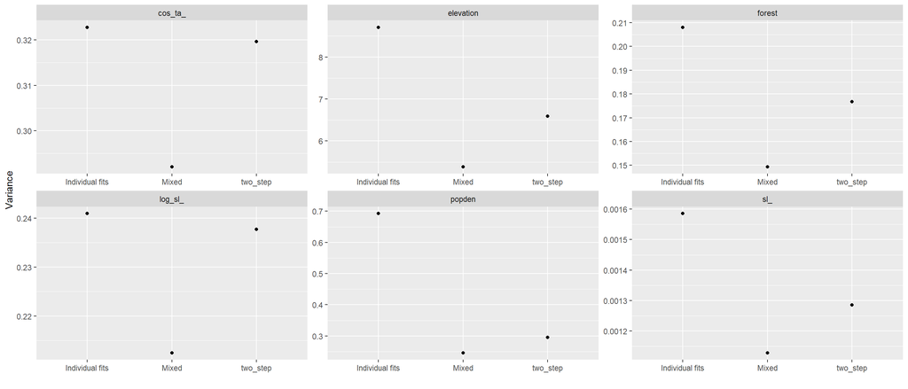

```r
ggplot(data = allvars, aes(x = method, y = sd)) +
  geom_point() +
  xlab("") + ylab("Variance") +
  facet_wrap(~term, scales="free")
```

## Individual Coefficients

Look at individual coefficients.

```r
#  Individual fits (we will also append asympototic normal-based CI
# for parameters in models fit to individuals)
ssf_coefs.se<-ssffits2 %>%
   mutate(conf.high = estimate + 1.96*std.error) %>%
   mutate(conf.low = estimate - 1.96*std.error) %>%
   mutate(method = "indiv_fits") %>%
  dplyr::select(id, term, estimate, method, conf.high, conf.low)

# Predicted coefficients from the mixed model
mixed_coefs <- coef(fisher.ssf)$cond$id[,-1]
mixed_coefs$id <- rownames(mixed_coefs)
mixed_coefs <- mixed_coefs %>%
  pivot_longer(c('elevation', 'forest', 'popden', "sl_", "log_sl_", "cos_ta_"),
               names_to="term", values_to="estimate") %>%
  mutate(method = "Mixed") %>%
  mutate(conf.high = NA) %>%
  mutate(conf.low = NA)

# Coefficients from the two-step approach (TS.Estim)
twostepcoefs<-matrix(twostep$beta,
                     nrow(twostep$r.effect),
                     ncol(twostep$r.effect), byrow=TRUE)+twostep$r.effect
twostepcoefs<-as.data.frame(twostepcoefs)
twostepcoefs$method<-"two_step"
twostepcoefs$id<-rownames(twostep$r.effect)
twostepcoefs<-twostepcoefs %>%
  pivot_longer(c('elevation', 'popden','forest', 'sl_', 'log_sl_', 'cos_ta_'),
               names_to="term", values_to="estimate")%>%
  dplyr::select(c(id, term, estimate, method))
twostepcoefs$conf.high <- twostepcoefs$conf.low <- NA
```

Combine individual estimates

```r
allests<-rbind(mixed_coefs, ssf_coefs.se, twostepcoefs)
```

### Plot results

Note here that a few coefficients for elevation and popdenshow considerable shrinkage. These are coefficients with large SEs as seen by inspecting the individual fits.

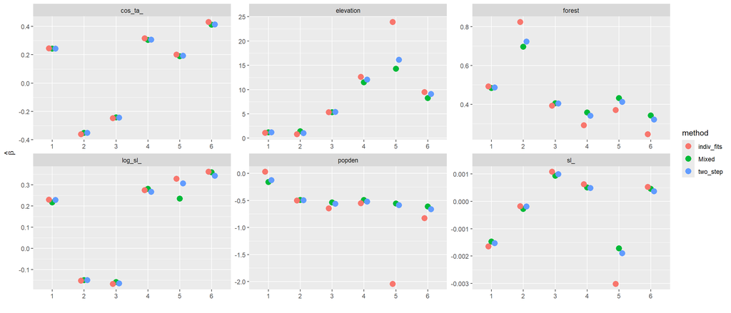

```r
ggplot(data=allests,
       aes(x=id, y=estimate, col=method))+
  geom_point(size=3.5, position=position_dodge(width=0.3))+
  xlab("")+ylab(expression(hat(beta)))+facet_wrap(~term, scales="free")
```

With SEs and dropping the two-step method

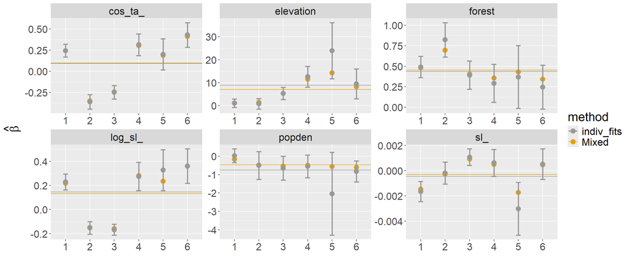

```r
cbp1 <- c("#999999", "#E69F00", "#56B4E9", "#009E73",
"#F0E442", "#0072B2", "#D55E00", "#CC79A7")
ggplot(data=allests[allests$method!="two_step",],
       aes(x=id, y=estimate, col=method))+
  geom_point(size=3.5)+
  xlab("")+ylab(expression(hat(beta)))+facet_wrap(~term, scales="free")+
  geom_hline(aes(yintercept=mean, col=method), betas1)+
  geom_hline(aes(yintercept=mean, col=method), betas2)+
  scale_colour_manual(values=cbp1)+
  theme(text = element_text(size=20))+
  geom_errorbar( aes(x=id, ymin=conf.low, ymax=conf.high),
                 width=0.2, size=1, data=ssf_coefs.se)
```

Total Elapsed time

```r
toc()
```

```
## total: 166.61 sec elapsed
```